# Homework 9

Shynggys Magzanov

11 11 2020

## Exercise 7.5.1.

### In this exercise we are given a random variable X that has a density of f(x). Our goal is to implement important sampling method to estimate second moment.

Part a. We need to implement important sampling algorithm using the standard normal density as our $g(x)$. Here our $h(x)=x^2$.

```r
isAppr <- function(n, h, df, dg, rg, ...) {
  x <- rg(n, ...)
  mean( h(x) * df(x) / dg(x, ...) )
}

h <- function(x) x^2
df <- function(x) 0.2 * x^2 * dnorm(x, mean = 2, sd = 1)
rg <- function(n) rnorm(n, mean = 0, sd = 1)
dg <- function(x) dnorm(x, mean = 0, sd = 1)

mySummary <- function(nrep, n, h, df, dg, rg) {
##    browser()
    sim <- replicate(nrep, isAppr(n, h, df, dg, rg))
    return(c(mean(sim), sd(sim)))
}

appr <- mySummary(100, 1000, h, df, dg, rg)
appr <- data.frame("Mean"=appr[1], "Std"=appr[2])

size <- c(10000, 50000)
for (i in size){
   temp <- mySummary(100, i, h, df, dg, rg)
   appr <- rbind(appr,temp)
}
appr
```

```
##       Mean      Std
## 1 8.362157 7.321190
## 2 8.943980 4.744532
## 3 8.881794 2.685700
```

Part b. Now we need to design better importance sampling method using different $g(x)$. Let us first plot $h(x)f(x)$

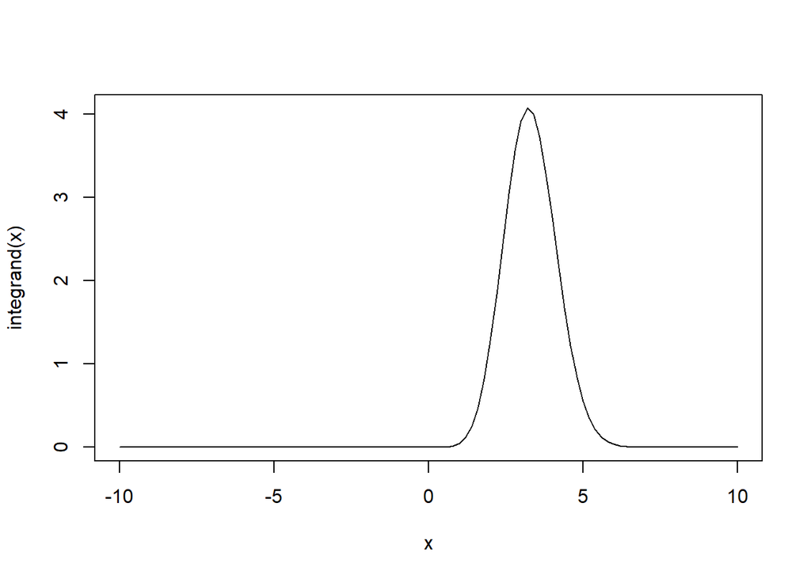

```r
h <- function(x) x^2
df <- function(x) 0.2 *x^2 * dnorm(x, mean = 2, sd = 1)
integrand <- function(x) h(x) * df(x)

curve(integrand, from = -10, to = 10)
```

This looks like a Normal distribution. After some empirical analysis $g(x)=N(3.25,0.8)$. Take a look at the graph below, where the red line represents $g(x)$ and the black one represents $f(x)*h(x)$.

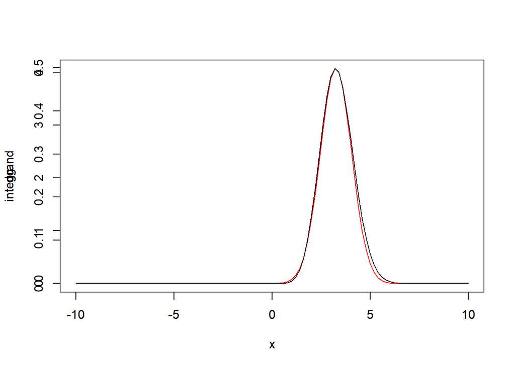

```r
dg <- function(x) dnorm(x, mean = 3.25, sd = 0.8)

plot(dg, from = -10, to = 10, col = "red")
par(new = TRUE)
plot.function(integrand, to = 10, from = -10)
```

Part c. Now we need to implement importance sampling method using the newly found $g(x)$.

```r
isAppr <- function(n, h, df, dg, rg, ...) {
  x <- rg(n, ...)
  mean( h(x) * df(x) / dg(x, ...) )
}

h <- function(x) x^2
df <- function(x) 0.2 * x^2 * dnorm(x, mean = 2, sd = 1)
rg <- function(n) rnorm(n, mean = 3.25, sd = 0.8)
dg <- function(x) dnorm(x, mean = 3.25, sd = 0.8)

mySummary <- function(nrep, n, h, df, dg, rg) {
##    browser()
    sim <- replicate(nrep, isAppr(n, h, df, dg, rg))
    return(c(mean(sim), sd(sim)))
}

appr <- mySummary(100, 1000, h, df, dg, rg)
appr <- data.frame("Mean"=appr[1], "Std"=appr[2])

size <- c(10000, 50000)
for (i in size){
   temp <- mySummary(100, i, h, df, dg, rg)
   appr <- rbind(appr,temp)
}
appr
```

```
##       Mean         Std
## 1 8.599132 0.035052356
## 2 8.597896 0.011144190
## 3 8.599768 0.005711255
```

## Exercise 7.5.2.

Part a. We need to implement sampling algorithm of the path of $S(t)$. Sample path of BM is implemented as follows:

```r
rBM <- function(n, tgrid, sigma) {
    tt <- c(0, tgrid)
    dt <- diff(tt)
    nt <- length(tgrid)
    dw <- matrix(rnorm(n * nt, sd = sigma * sqrt(dt)), n, nt, byrow = TRUE)
    t(apply(dw, 1, cumsum))
}
```

```r
callValLognorm <- function(S0, K, mu, sigma) {
    d <- (log(S0 / K) + mu + sigma^2) / sigma
    S0 * exp(mu + 0.5 * sigma^2) * pnorm(d) - K * pnorm(d - sigma)
}
```

```r
optValueAppr <- function(n, r, sigma, S0, K, tgrid) {
    wt <- rBM(n, tgrid, sigma)
    ## payoff of call option on arithmetic average
    nt <- length(tgrid)
    TT <- tgrid[nt]
    St <- S0 * exp((r - sigma^2 / 2) * matrix(tgrid, n, nt, byrow = TRUE) + wt)
    pAri <- pmax(rowMeans(St) - K, 0)* exp(-r * TT)

    ## underlying asset price
    ST <- St[, nt]

    ## value of standard option
    pStd <- pmax(ST - K, 0)* exp(-r * TT)

    ## payoff of call option on geometric average
    pGeo <- pmax(exp(rowMeans(log(St))) - K, 0)* exp(-r * TT)

    ## sim <- data.frame(pAri, ST, pStd, pGeo)
    ## result
    return(c(cor(pAri, ST), cor(pAri, pStd), cor(pAri, pGeo)) )
}
```

Part b. Now we fix $\sigma = 0.5, T=1$. And for each value of $K \in \{1.1,1.2,1.3,1.4,1.5\}$ we simulate 5000 sample paths of S(t) to get MC estimates of correlations between $P_{A}$ and $S(T)$, $P_{A}$ and $P_E$, P_A and $P_{G}$.

```r
r <- 0.05; sigma <- 0.5; S0 <-  1; K <-  c(1.2, 1.3, 1.4, 1.5)
tgrid <-  seq(0, 1, length = 12)[-1]

sim <- replicate(200, optValueAppr(5000, r, sigma, S0, 1.1, tgrid))
correlations <- apply(sim, 1, mean)
correlations <- data.frame("S(t) and Arith Asian"=correlations[1], "European and Arith Asian"=correlations[2],
                           "Geo Asian and Arith Asian" = correlations[3])

for (k in K){
  sim <- replicate(200, optValueAppr(5000, r, sigma, S0, k, tgrid))
  correlations <- rbind( correlations, apply(sim, 1, mean))
}
correlations
```

```
##   S.t..and.Arith.Asian European.and.Arith.Asian Geo.Asian.and.Arith.Asian
## 1            0.8040063                0.8500162                 0.9969851
## 2            0.7632102                0.8400962                 0.9961304
## 3            0.7136633                0.8245028                 0.9949564
## 4            0.6640921                0.8086663                 0.9932592
## 5            0.6122111                0.7899293                 0.9912228
```

It can be seen that as K increases the all the positive correlations decline.

Part c. Now we fix $T=1, K=1.5$. We do the same procedure as in Part b but with varying $\sigma \in \{0.2,0.3,0.4,0.5\}$.

```r
r <- 0.05; sigma <- c(0.3, 0.4, 0.5); S0 <-  1; K <-  1.5
tgrid <-  seq(0, 1, length = 13)[-1]

sim <- replicate(200, optValueAppr(5000, r, 0.2, S0, K, tgrid))
correlations <- apply(sim, 1, mean)
correlations <- data.frame("S(t) and Arith Asian"=correlations[1], "European and Arith Asian"=correlations[2],
                           "Geo Asian and Arith Asian" = correlations[3])

for (s in sigma){
  sim <- replicate(200, optValueAppr(5000, r, s, S0, K, tgrid))
  correlations <- rbind( correlations, apply(sim, 1, mean))
}
correlations
```

```
##   S.t..and.Arith.Asian European.and.Arith.Asian Geo.Asian.and.Arith.Asian
## 1                   NA                       NA                        NA
## 2            0.3335848                0.6371624                 0.9875742
## 3            0.5021431                0.7401858                 0.9901635
## 4            0.6100865                0.7876883                 0.9911165
```

It can be seen that as $\sigma$ increases, positive correlations increase.

Part d. Now we set $\sigma=0.5, K=1.5$. We do the same procedure as in Part c but with varying $T \in \{0.4, 0.7, 1, 1.3, 1.6\}$.

```r
r <- 0.05; sigma <- 0.5; S0 <-  1; K <-  1.5 ; T <- c(0.7, 1, 1.3, 1.6)
tgrid <-  seq(0, 0.4, length = 13)[-1]

sim <- replicate(200, optValueAppr(5000, r, sigma, S0, K, tgrid))
correlations <- apply(sim, 1, mean)
correlations <- data.frame("S(t) and Arith Asian"=correlations[1], "European and Arith Asian"=correlations[2],
                           "Geo Asian and Arith Asian" = correlations[3])

for (t in T){
  tgrid <-  seq(0, t, length = 12)[-1]
  sim <- replicate(200, optValueAppr(5000, r, s, S0, K, tgrid))
  correlations <- rbind( correlations, apply(sim, 1, mean))
}
correlations
```

```
##   S.t..and.Arith.Asian European.and.Arith.Asian Geo.Asian.and.Arith.Asian
## 1            0.3402469                0.6455532                 0.9881427
## 2            0.5187461                0.7526139                 0.9909063
## 3            0.6135310                0.7932251                 0.9911508
## 4            0.6694590                0.8088599                 0.9908731
## 5            0.7110594                0.8223604                 0.9903913
```

Part e. Now we set $\sigma=0.4, T=1, K=1.5$. By using $P_G$ as a control variate we need to develop a control variate MC estimator for $E[P_A]$.

```r
optValueAppr_2 <- function(n, r, sigma, S0, K, tgrid) {
    wt <- rBM(n, tgrid, sigma)
    ## payoff of call option on arithmetic average
    nt <- length(tgrid)
    TT <- tgrid[nt]
    St <- S0 * exp((r - sigma^2 / 2) * matrix(tgrid, n, nt, byrow = TRUE) + wt)
    pAri <- pmax(rowMeans(St) - K, 0)
    vAri <- mean(pAri)

    ## payoff of call option on geometric average
    pGeo <- pmax(exp(rowMeans(log(St))) - K, 0)
    tbar <- mean(tgrid)
    sBar2 <- sigma^2 / nt^2 / tbar * sum( (2 * seq(nt) - 1) * rev(tgrid) )
    pGeoTrue <- callValLognorm(S0, K, (r - 0.5 * sigma^2) * tbar,
                               sqrt(sBar2 * tbar))
    vGeo <- vAri - cov(pGeo, pAri) / var(pGeo) * (mean(pGeo) - pGeoTrue)
    ## sim <- data.frame(pAri, ST, pStd, pGeo)
    ## result
    return(c(vAri, vGeo) * exp(-r * TT))
}
```

```r
r <- 0.05; sigma <- 0.4; S0 <-  1; K <-  1.5
tgrid <-  seq(0, 1, length = 13)[-1]
sim <- replicate(200, optValueAppr_2(5000, r, sigma, S0, K, tgrid))
values <- apply(sim, 1, mean)
values <- data.frame("Value with no VC" = values[1], "Value with P_G as VC" = values[2])
values
```

```
##   Value.with.no.VC Value.with.P_G.as.VC
## 1      0.008965617           0.00886046
```

```r
sds <- apply(sim, 1, sd)
sds <- data.frame("Value with no VC" = sds[1], "Value with P_G as VC" = sds[2])
sds
```

```
##   Value.with.no.VC Value.with.P_G.as.VC
## 1     0.0007311676         0.0001056643
```

Take a look at the SD when using $P_G$ as a control variate. It is way less than when without one. It shows that the variance was reduced indeed.